# Statistical evidence for or against traveling to Pune

# Library imports

```r
library(tidyverse)
library(ggplot2)
```

# Probability

```r
N <- 9426959 # Population of Pune
area <- 331 # in km^2
pd <- N/area # Population Density
npp <- 1348 # Number of positive cases of COVID-19 in Pune

Pp <- npp/N # Probability that any random person in Pune is infected
Pp
```

```
[1] 0.0001429942
```

```r
pGh <- 2109 #Population of Ghorpadi
pKh <- 2036 #Population of Kharadi

pGh + pKh # Population I would be exposed to every day
```

```
[1] 4145
```

## Maharashtra Data

```r
nM <- 101000 # Confirmed
nR <- 47796 # Recovered
nD <- 3717 # Deaths

nP <- 11420000

nMaharashtra <- (nM+nR+nD)/nP # Probability of infection in Maharashtra

nMaharashtra
```

```
[1] 0.0133549
```

## Karnataka Data

```r
nM <- 6516
nR <- 3440
nD <- 79

nP <- 641000

nKarnataka <- (nM+nR+nD)/nP # Probability of infection in Karnata

nKarnataka
```

```
[1] 0.01565523
```

## Probability of infection during travel

```r
nMaharashtra + nKarnataka
```

```
[1] 0.02901013
```

# Age group wise distribution of infection

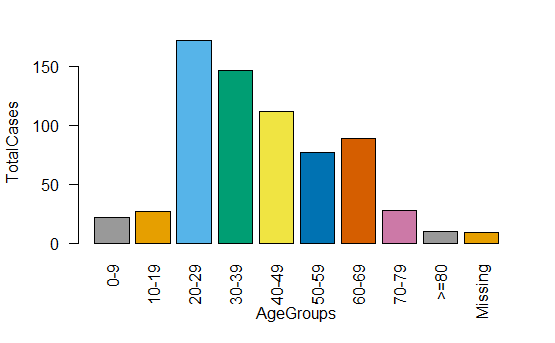

```r
color_blind_friendly_cols <- c("#999999", "#E69F00" , "#56B4E9", "#009E73", "#F0E442", "#0072B2", "#D55E00", "#CC79A7")

AgeGroupDetails <- read.csv(file = "AgeGroupDetails.csv")


barplot(AgeGroupDetails$TotalCases, names.arg = AgeGroupDetails$AgeGroup, xlab = "AgeGroups", ylab = "TotalCases", col = color_blind_friendly_cols,las=2)
```

This graph shows that the age group of 20-29 contains the most number of infections.

# Statewise distribution of infection

```r
covid19 <- read.csv(file = "covid_19_india.csv")
```

```r
c2 <- covid19 %>% group_by(State.UnionTerritory) %>%
  filter(Date == max(Date)) %>% select(State.UnionTerritory, Confirmed, Cured, Deaths) %>% mutate(Total = Confirmed + Cured + Deaths) %>% arrange(desc(Total))

c2
```

| State.UnionTerritory | Confirmed | Cured | Deaths | Total |
| --- | --- | --- | --- | --- |
| Maharashtra | 65168 | 28081 | 2197 | 95446 |
| Tamil Nadu | 21184 | 12000 | 160 | 33344 |
| Delhi | 18549 | 8075 | 416 | 27040 |
| Gujarat | 16343 | 9230 | 1007 | 26580 |
| Rajasthan | 8617 | 5739 | 193 | 14549 |
| Madhya Pradesh | 7891 | 4444 | 343 | 12678 |
| Uttar Pradesh | 7445 | 4410 | 201 | 12056 |
| West Bengal | 5130 | 1970 | 309 | 7409 |
| Telangana | 4737 | 2352 | 182 | 7271 |
| Andhra Pradesh | 3569 | 2289 | 60 | 5918 |

[output cut: 30 more lines]

# Maharashtra vs Kerala Ranking

```r
rTMah <- which(c2$State.UnionTerritory == "Maharashtra")
rTKer <- which(c2$State.UnionTerritory == "Kerala")

cat("Maharashtra's Rank in Total cases: ",rTMah,"Kerala's Rank in Total cases: ",rTKer, fill = TRUE)
```

```
Maharashtra's Rank in Total cases:  1
Kerala's Rank in Total cases:  19
```

```r
c3 <- c2 %>% arrange(desc(Deaths))
c4 <- c2 %>% arrange(desc(Confirmed))
```

```r
rDMah <- which(c3$State.UnionTerritory == "Maharashtra")
rDKer <- which(c3$State.UnionTerritory == "Kerala")


cat("Maharashtra's Rank in Deaths: ",rDMah, "Kerala's Rank in Deaths: ",rDKer, fill = TRUE)
```

```
Maharashtra's Rank in Deaths:  1
Kerala's Rank in Deaths:  17
```

```r
rCMah <- which(c4$State.UnionTerritory == "Maharashtra")
rCKer <- which(c4$State.UnionTerritory == "Kerala")

cat("Maharashtra's Rank in Confirmed cases: ",rCMah ,"Kerala's Rank in Confirmed cases: ",rCKer, fill = TRUE)
```

```
Maharashtra's Rank in Confirmed cases:  1
Kerala's Rank in Confirmed cases:  19
```

# Time Series analysis

## Total deaths

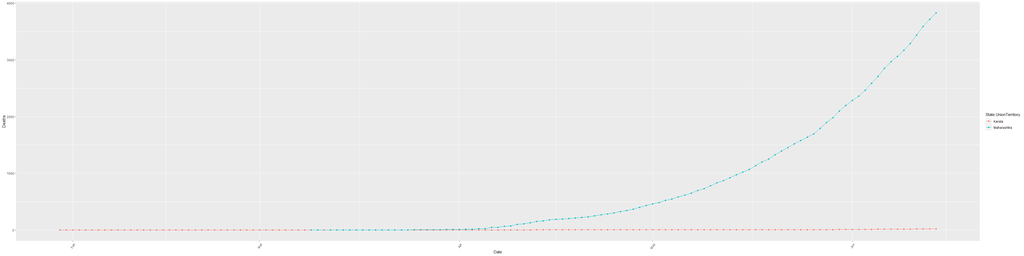

```r
covid19 %>% mutate(Date = as.Date(Date, format = "%d/%m/%Y") ) %>% filter(State.UnionTerritory %in% c("Maharashtra", "Kerala"), !is.na(Deaths), !is.na(Date))  %>%
    ggplot(aes(Date, Deaths, col = State.UnionTerritory)) + geom_point() +
    geom_line() + theme(axis.text.x = element_text(angle = 60, hjust = 1))
```

As observed the graph for Maharashtra is rising exponentially whereas Kerala is constant. This is evidence that Kerala is a much safer state as of now in terms of Corona virus spread for Deaths.

## Confirmed Cases

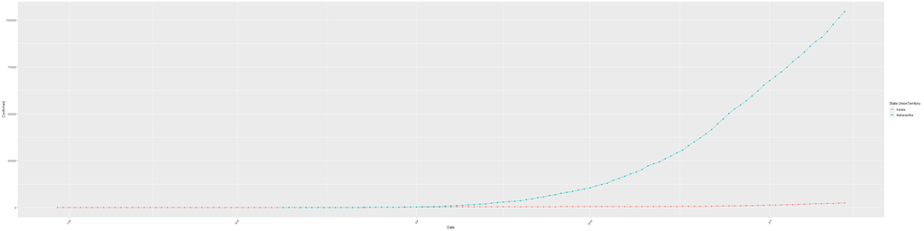

```r
covid19 %>% mutate(Date = as.Date(Date, format = "%d/%m/%Y") ) %>% filter(State.UnionTerritory %in% c("Maharashtra", "Kerala"), !is.na(Confirmed), !is.na(Date))  %>%
    ggplot(aes(Date, Confirmed, col = State.UnionTerritory)) + geom_point() +
    geom_line() + theme(axis.text.x = element_text(angle = 60, hjust = 1))
```

As observed the graph for Maharashtra is rising exponentially whereas Kerala is constant. This is evidence that Kerala is a much safer state as of now in terms of Corona virus spread for confirmed cases.

## Total Cases

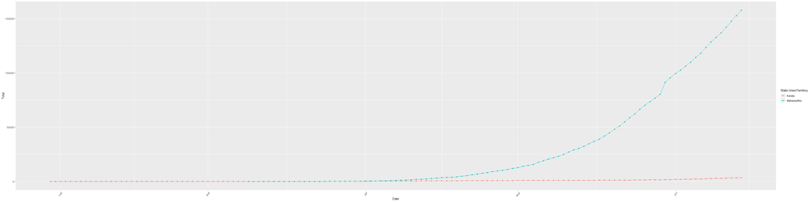

```r
covid19 %>% mutate(Date = as.Date(Date, format = "%d/%m/%Y"), Total = (Confirmed + Deaths + Cured) ) %>% filter(State.UnionTerritory %in% c("Maharashtra", "Kerala"), !is.na(Total), !is.na(Date))  %>%
    ggplot(aes(Date, Total, col = State.UnionTerritory)) + geom_point() +
    geom_line() + theme(axis.text.x = element_text(angle = 60, hjust = 1))
```

As observed the graph for Maharashtra is rising exponentially whereas Kerala is constant. This is evidence that Kerala is a much safer state as of now in terms of Corona virus spread for Total cases.

# Hospital Beds Data

```r
hData <- read.csv("HospitalBedsIndia.csv")
```

```
There were 36 warnings (use warnings() to see them)
```

```r
hDataK <- filter(hData, State.UT == "Kerala")
hDataM <- filter(hData, State.UT == "Maharashtra")

Kerala <- c(hDataK$NumPrimaryHealthCenters_HMIS, hDataK$NumCommunityHealthCenters_HMIS, hDataK$NumSubDistrictHospitals_HMIS, hDataK$NumDistrictHospitals_HMIS, hDataK$TotalPublicHealthFacilities_HMIS, hDataK$NumPublicBeds_HMIS, hDataK$NumRuralHospitals_NHP18, hDataK$NumRuralBeds_NHP18, hDataK$NumUrbanHospitals_NHP18, hDataK$NumUrbanBeds_NHP18)


Maharashtra <- c(hDataM$NumPrimaryHealthCenters_HMIS, hDataM$NumCommunityHealthCenters_HMIS, hDataM$NumSubDistrictHospitals_HMIS, hDataM$NumDistrictHospitals_HMIS, hDataM$TotalPublicHealthFacilities_HMIS, hDataM$NumPublicBeds_HMIS, hDataM$NumRuralHospitals_NHP18, hDataM$NumRuralBeds_NHP18, hDataM$NumUrbanHospitals_NHP18, hDataM$NumUrbanBeds_NHP18)
```

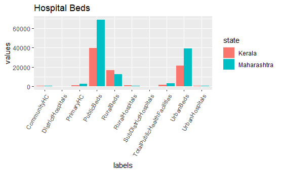

```r
labels <- rep(c("PrimaryHC", "CommunityHC", "SubDistrictHospitals", "DistrictHospitals", "TotalPublicHealthFacilities", "PublicBeds", "RuralHospitals", "RuralBeds", "UrbanHospitals", "UrbanBeds"),2)

values <- c(Kerala,Maharashtra)

d <- data.frame(labels, values)
state <- c(rep("Kerala",10), rep("Maharashtra", 10))
p <- ggplot(d, aes(labels, values)) + geom_bar(stat = "identity", aes(fill = state), position = "dodge") +  ggtitle("Hospital Beds") + theme(axis.text.x = element_text(angle = 60, hjust = 1))
p
```

This displays that Kerala has lesser hospital facility than Maharashtra and yet, the number of cases is greater in Maharashtra indicating that the conditions for transmission is more suitable in Maharahshtra as opposed to Kerala.

# Case details

```r
idC <- read.csv("IndividualDetails.csv")

nP <- as.numeric(count(filter(idC, detected_district == "Pune")))
nM <- as.numeric(count(filter(idC, detected_district == "Kannur")))

cat("Number of Cases in Pune:", nP,"\n", "Number of Cases in Kannur:", nM, fill = TRUE)
```

```
Number of Cases in Pune: 706

Number of Cases in Kannur: 111
```

This is also evidence that Kannur is safer than Pune.